# Quick analysis of C084

Peter Hickey https://peterhickey.org (WEHI SCORE)https://www.wehi.edu.au/people/shalin-naik/3310/score  
2020-03-23

# Setting up the data

## Incorporating cell-based annotation

### Summarising the data

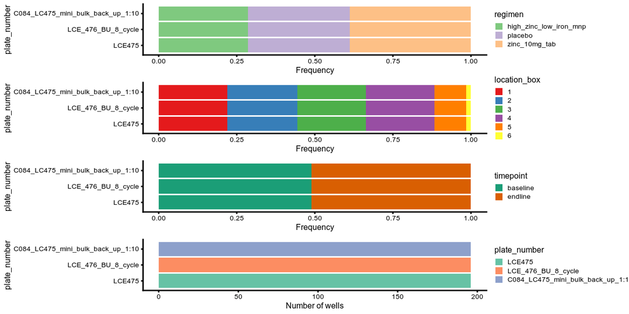

Figure 1: Breakdown of the samples by plate.

|  | plate_number | well_position | rpi | well_position_in_original_dilution_layout | sequencing_run | id | group | collection_date | sample_serum | rna | cytof_1 | cytof_2 | location_box | position | timepoint | UMI_deduped | regimen |
| --- | --- | --- | --- | --- | --- | --- | --- | --- | --- | --- | --- | --- | --- | --- | --- | --- | --- |
| LCE475_E1.not_UMI_deduped | LCE475 | E1 | RPI 10 | A1 | NN179 | 301 | A | 2018-08-29 | TRUE | TRUE | TRUE | TRUE | 1 | 1,2,3,4 | baseline | FALSE | high_zinc_low_iron_mnp |
| LCE475_E10.not_UMI_deduped | LCE475 | E10 | RPI 10 | A10 | NN179 | 139 | B | 2018-09-20 | TRUE | TRUE | TRUE | TRUE | 1 | 42,43,44,45 | baseline | FALSE | zinc_10mg_tab |
| LCE475_E11.not_UMI_deduped | LCE475 | E11 | RPI 10 | A11 | NN179 | 303 | A | 2018-09-20 | TRUE | TRUE | TRUE | TRUE | 1 | 46,47,48,49 | baseline | FALSE | high_zinc_low_iron_mnp |
| LCE475_E12.not_UMI_deduped | LCE475 | E12 | RPI 10 | A12 | NN179 | 305 | A | 2018-09-26 | TRUE | TRUE | TRUE | TRUE | 1 | 54,55,56,57 | baseline | FALSE | high_zinc_low_iron_mnp |
| LCE475_E13.not_UMI_deduped | LCE475 | E13 | RPI 10 | A13 | NN179 | 140 | B | 2018-09-26 | TRUE | TRUE | TRUE | TRUE | 1 | 58,59,60,61 | baseline | FALSE | zinc_10mg_tab |
| LCE475_E14.not_UMI_deduped | LCE475 | E14 | RPI 10 | A14 | NN179 | 306 | A | 2018-09-27 | TRUE | TRUE | TRUE | TRUE | 1 | 62,63,64,65 | baseline | FALSE | high_zinc_low_iron_mnp |
| LCE475_E15.not_UMI_deduped | LCE475 | E15 | RPI 10 | A15 | NN179 | 337 | B | 2018-10-03 | TRUE | TRUE | TRUE | TRUE | 1 | 66,67,68,69 | baseline | FALSE | zinc_10mg_tab |
| LCE475_E16.not_UMI_deduped | LCE475 | E16 | RPI 10 | A16 | NN179 | 375 | C | 2018-10-03 | TRUE | TRUE | TRUE | TRUE | 1 | 70,71,72,73 | baseline | FALSE | placebo |
| LCE475_E17.not_UMI_deduped | LCE475 | E17 | RPI 10 | A17 | NN179 | 376 | C | 2018-10-04 | TRUE | TRUE | TRUE | TRUE | 1 | 74,75,76,77 | baseline | FALSE | placebo |
| LCE475_E18.not_UMI_deduped | LCE475 | E18 | RPI 10 | A18 | NN179 | 141 | B | 2018-10-04 | TRUE | TRUE | TRUE | TRUE | 1 | 78,79,80,81 | baseline | FALSE | zinc_10mg_tab |

[output cut: 578 more lines]

## Incorporating gene-based annotation

# Quality control of cells

## Defining the quality control metrics

## Visualizing the QC metrics

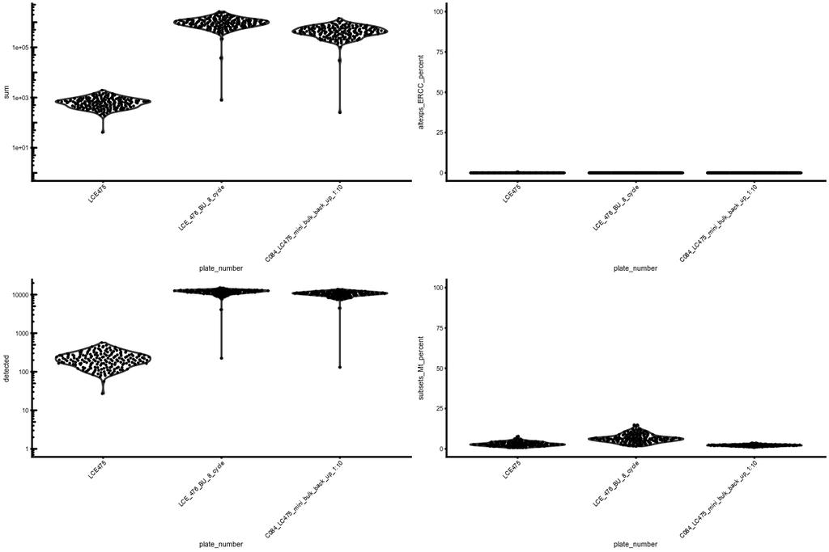

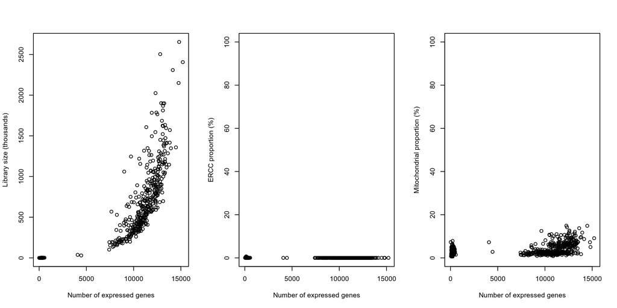

## Identifying outliers by each metric

Table 1: QC cutoffs

| plate_number | total counts | total features | %ERCC | %mito |
| --- | --- | --- | --- | --- |
| C084_LC475_mini_bulk_back_up_1:10 | 95896.1 | 7460.7 | 0 | 3.8 |
| LCE_476_BU_8_cycle | 263573.9 | 8850.2 | 0 | 12.7 |
| LCE475 | 162405.2 | 8085.2 | 0 | 5.7 |

Table 2: Number of samples removed by each QC step and the number of samples remaining, ordered by the percentage of cells remaining.

| plate_number | ByLibSize | ByFeature | BySpike | ByMito | Remaining | PercRemaining |
| --- | --- | --- | --- | --- | --- | --- |
| C084_LC475_mini_bulk_back_up_1:10 | 2 | 4 | 10 | 0 | 183 | 93.4 |
| LCE_476_BU_8_cycle | 3 | 7 | 9 | 4 | 176 | 89.8 |
| LCE475 | 196 | 196 | 51 | 6 | 0 | 0.0 |

### Summary

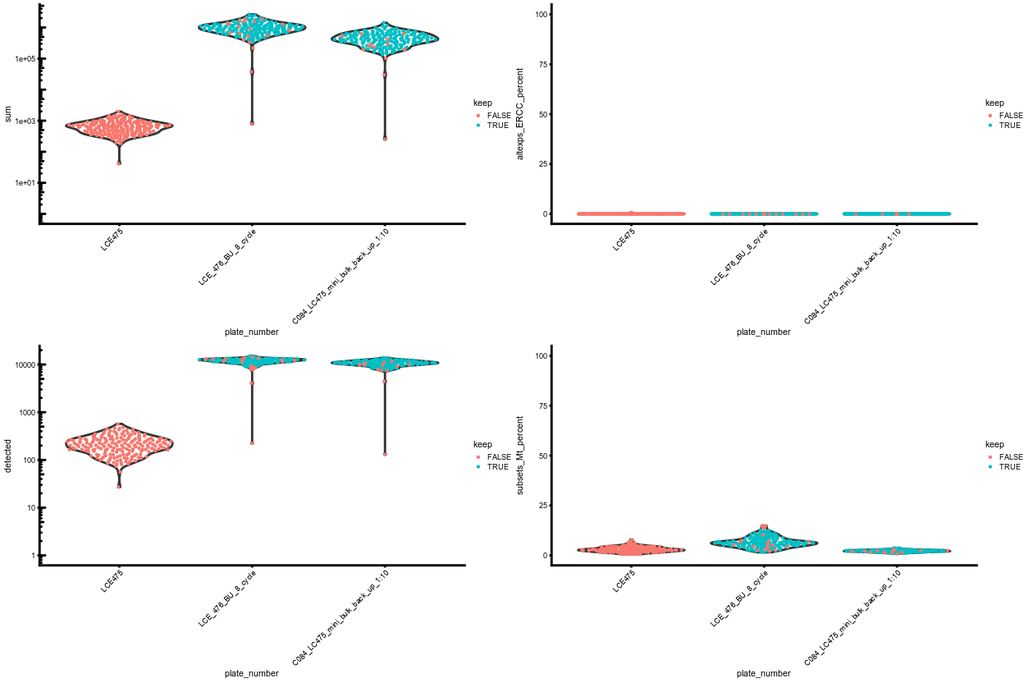

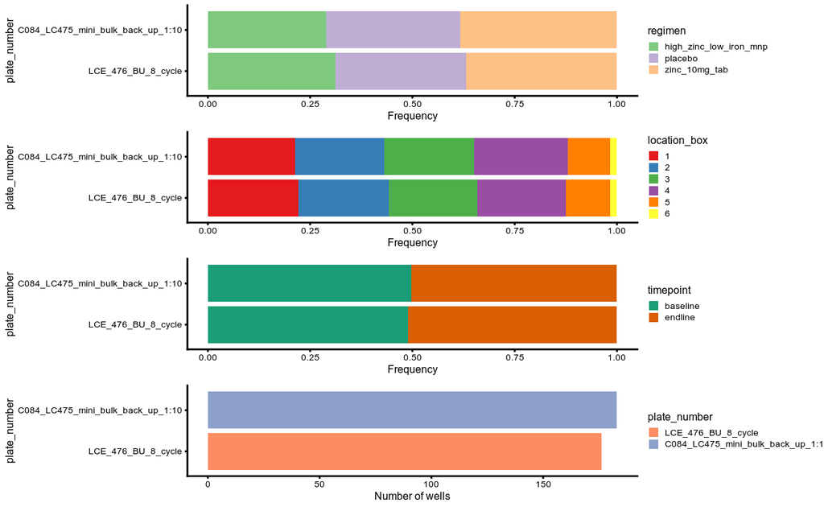

# Examining gene-level metrics

## Inspecting the most highly expressed genes

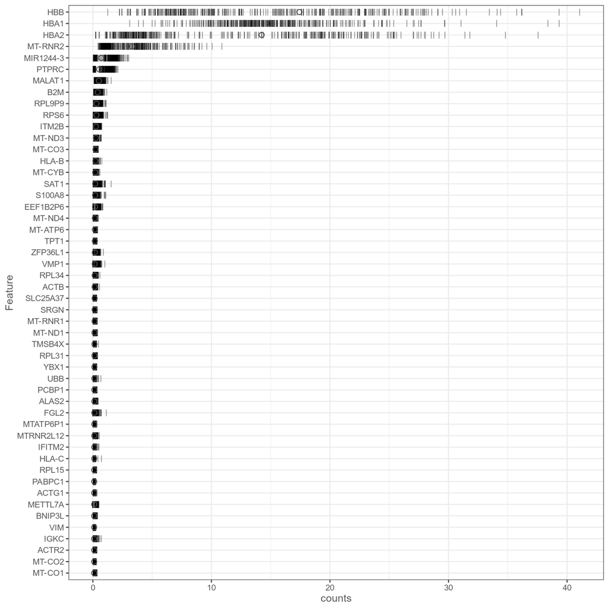

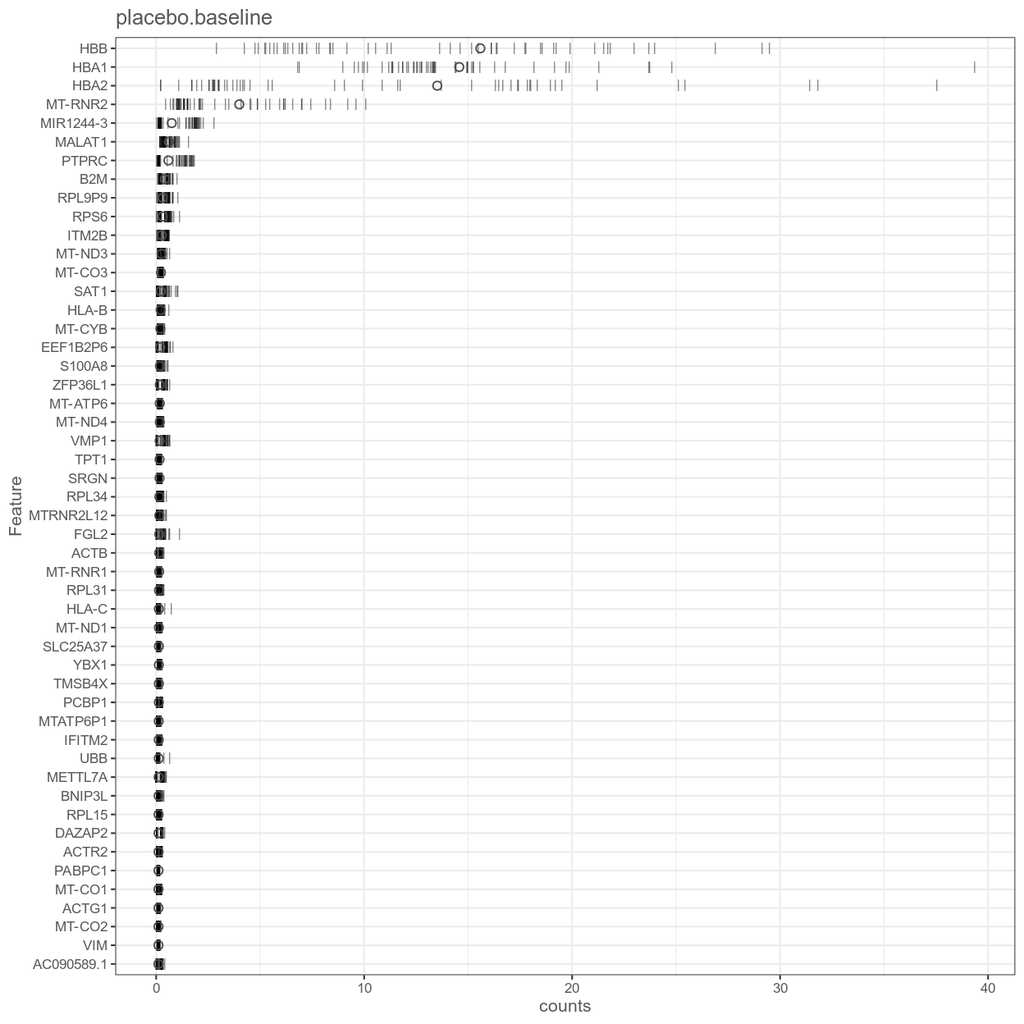

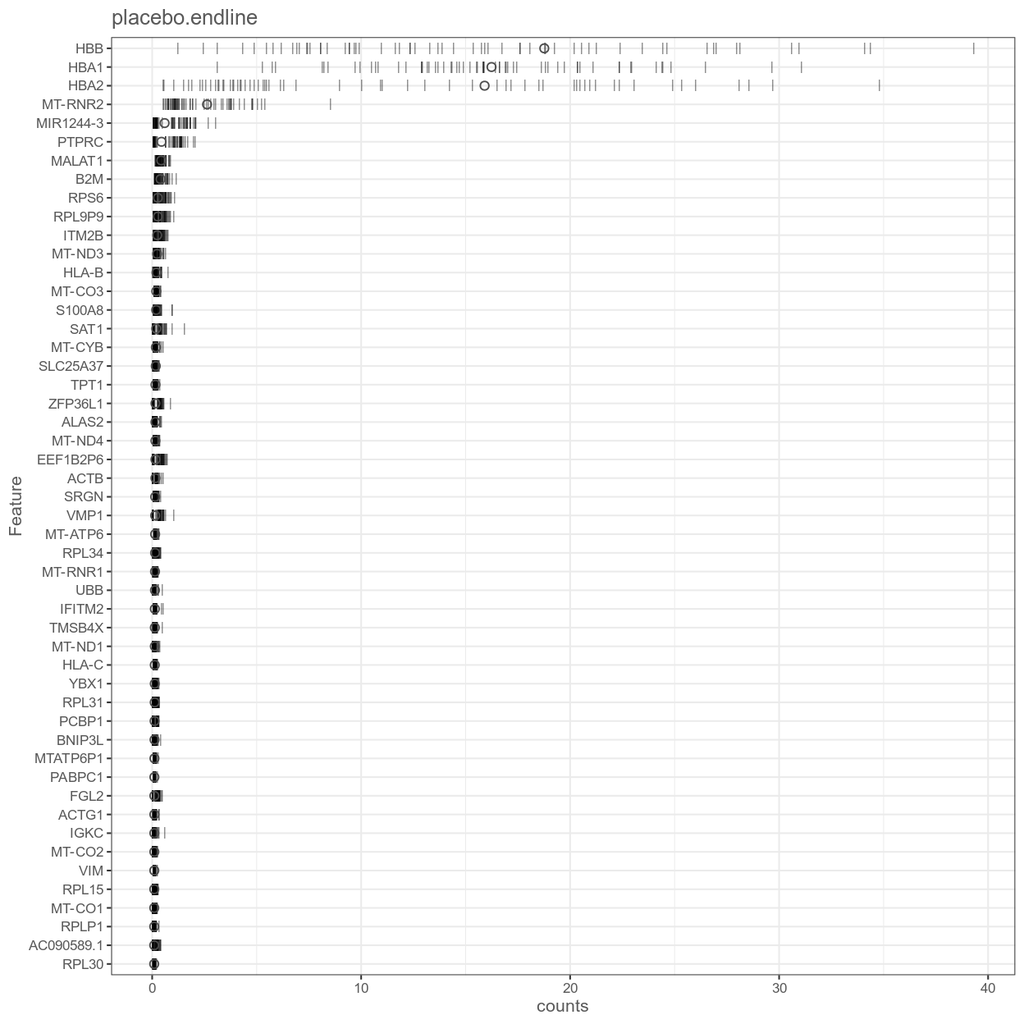

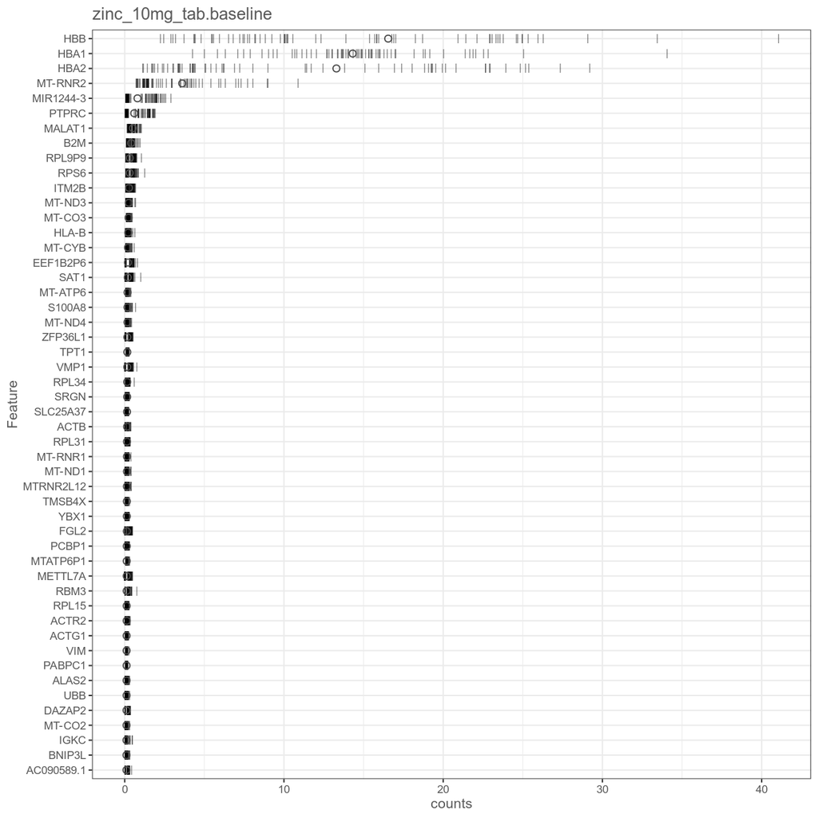

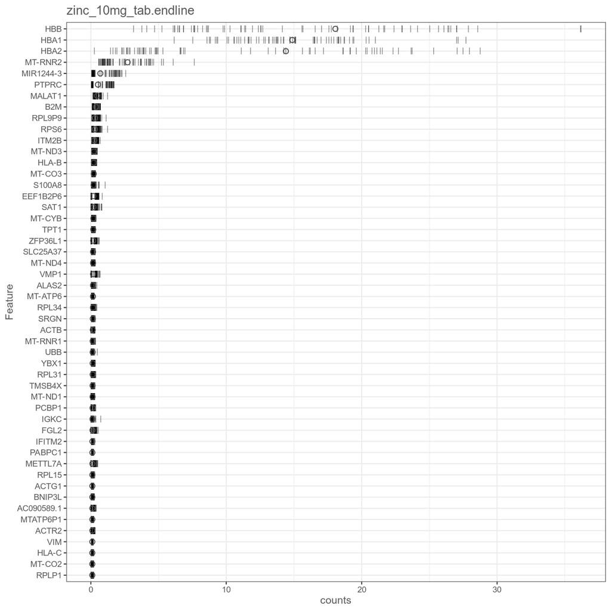

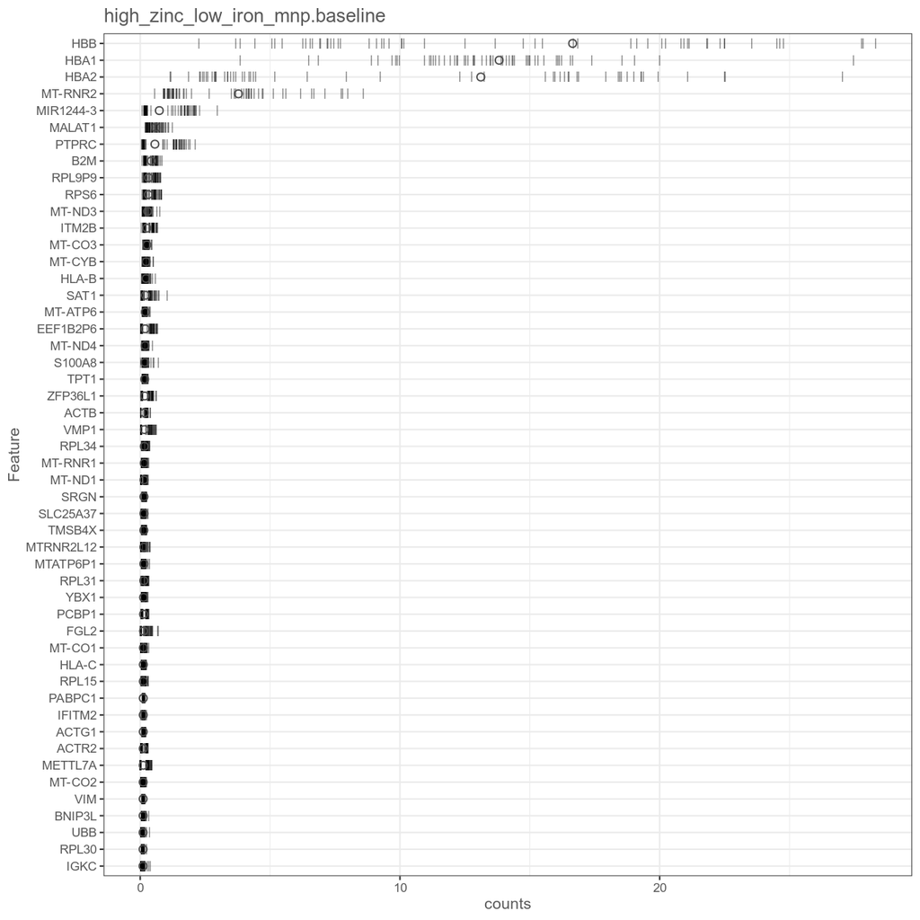

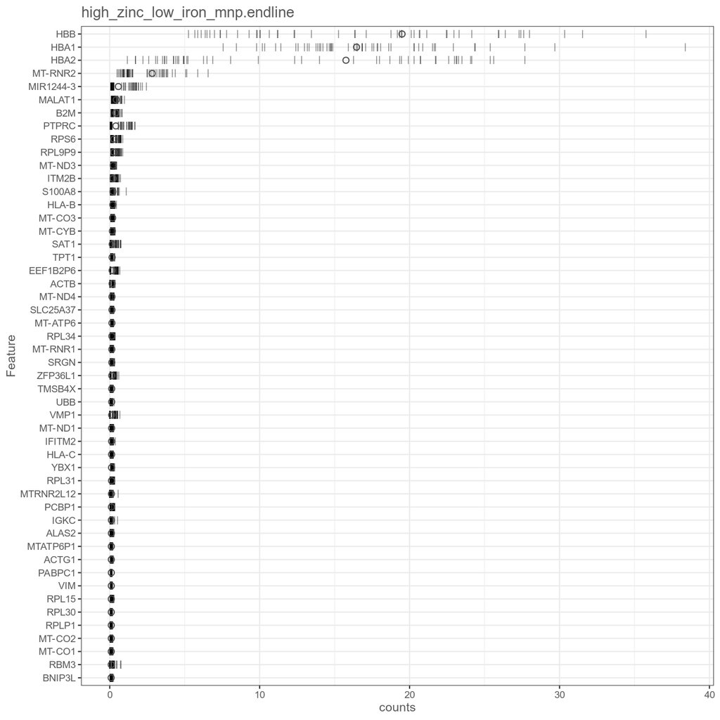

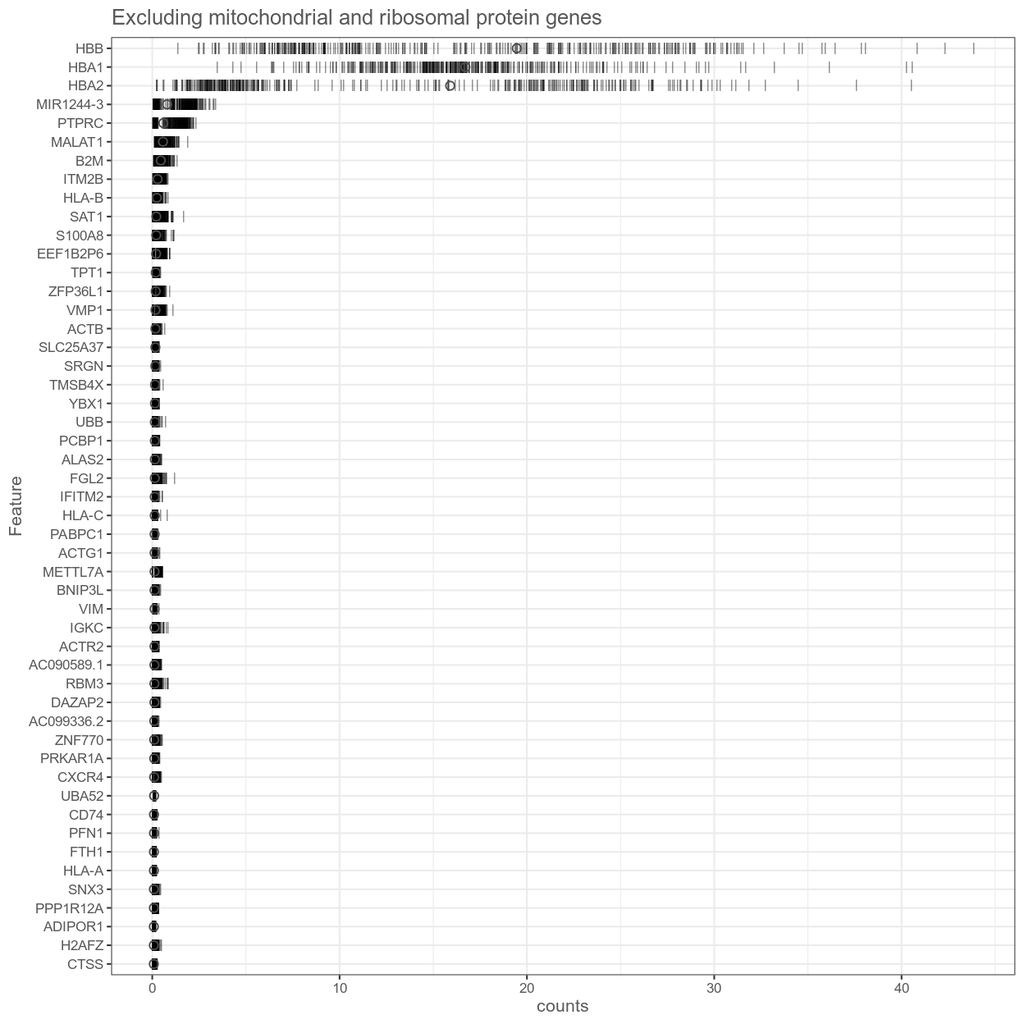

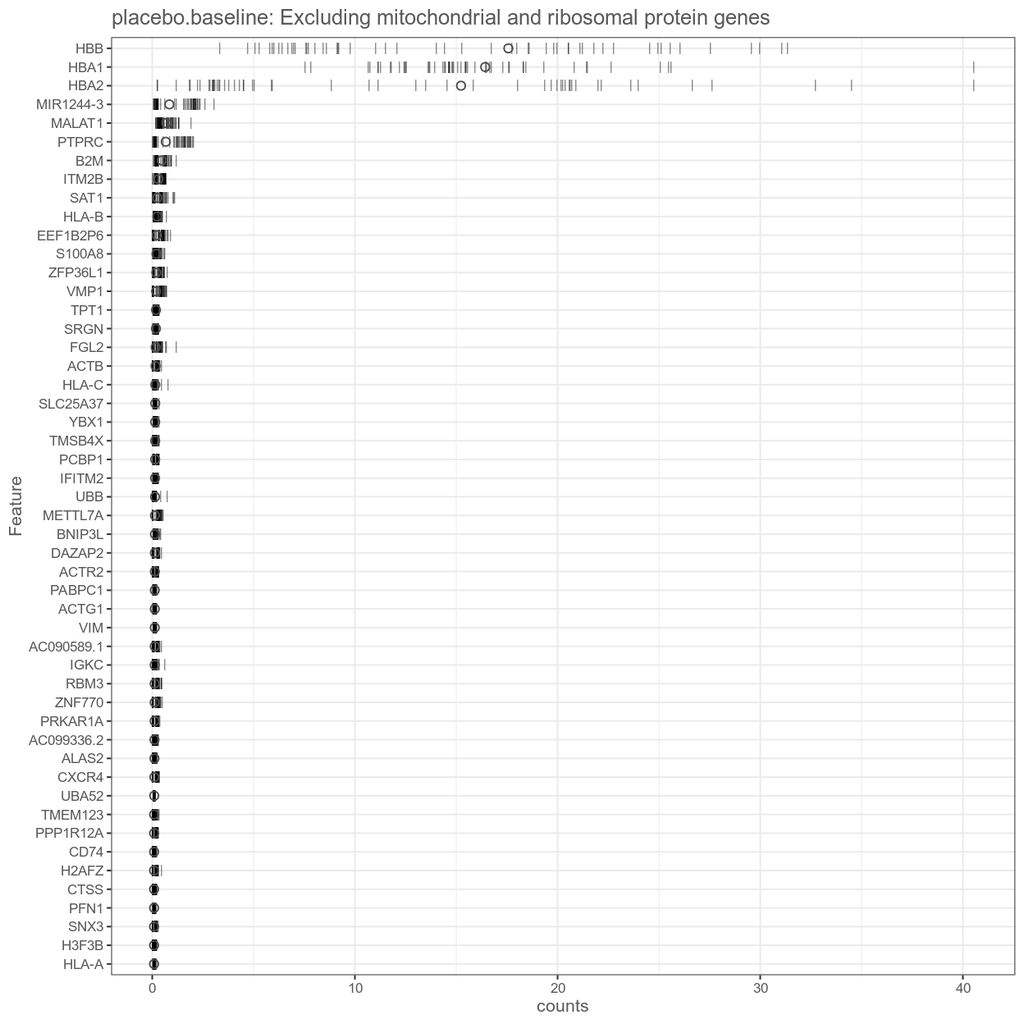

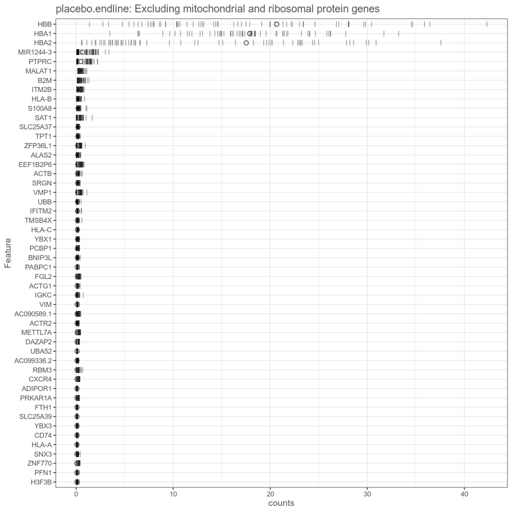

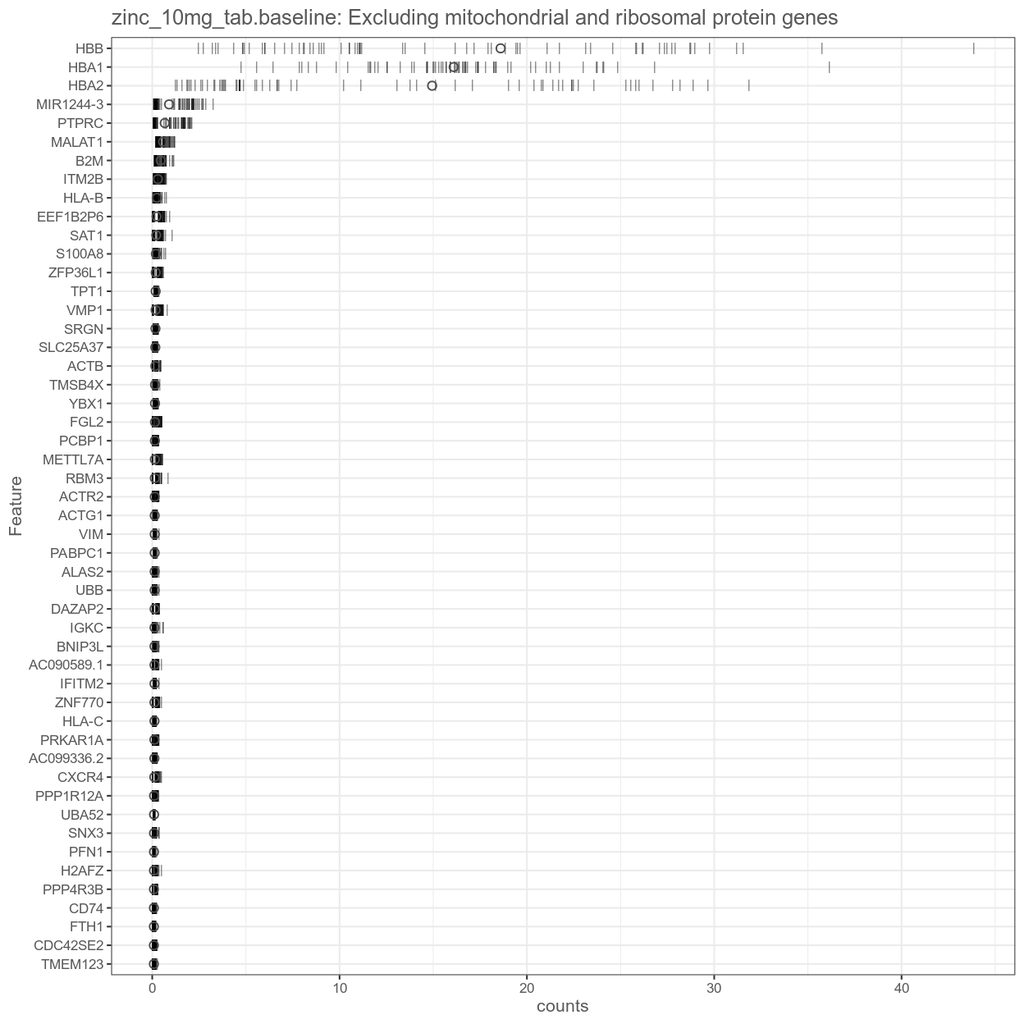

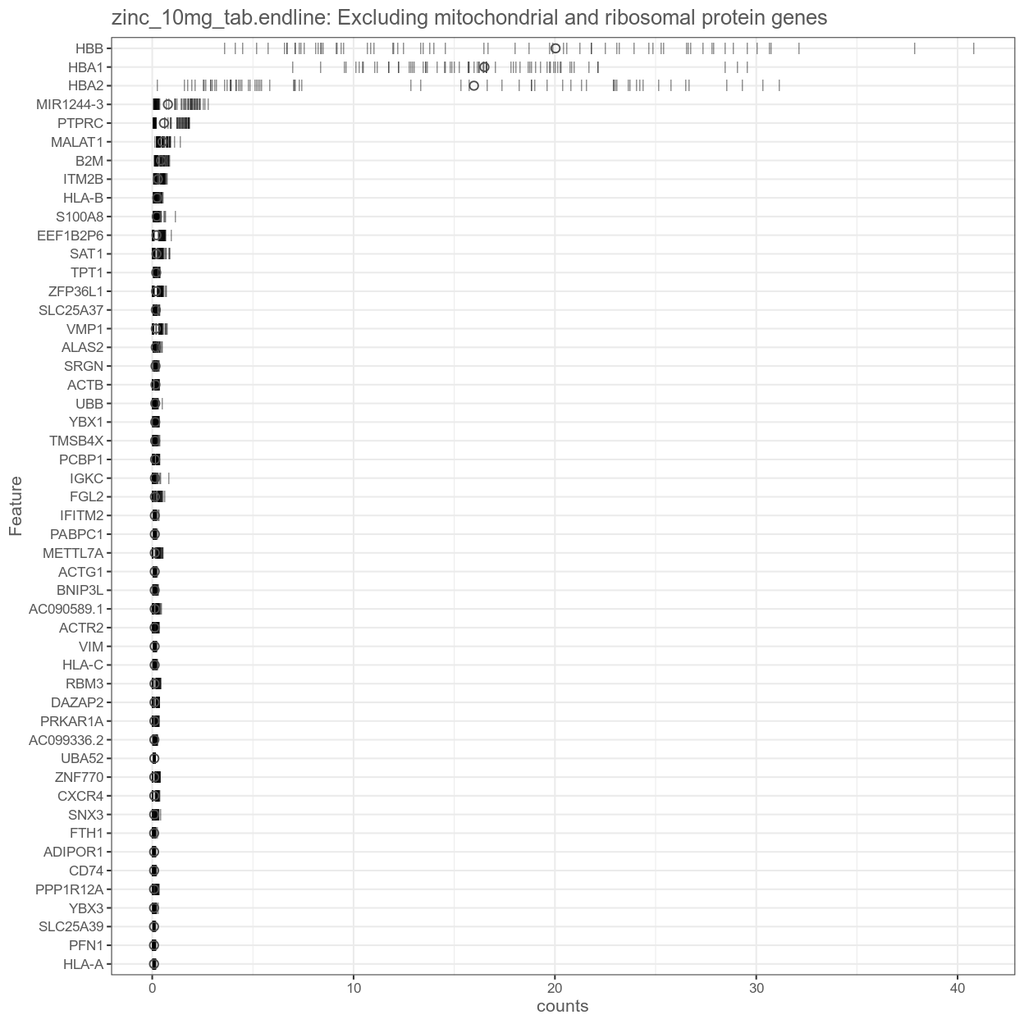

[2 more figures not shown]

## Filtering out low-abundance genes

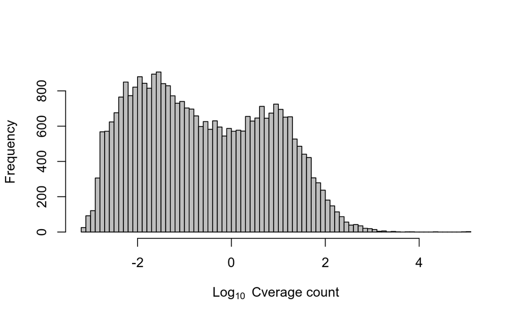

Figure 2: Histogram of log-average counts for all genes in the combined data set.

We remove 312 genes that are not expressed in any cell. Such genes provide no information and would be removed by any filtering strategy. We retain 32545 for downstream analysis.

# Normalization of cell-specific biases

**TODO:** Try other size factors (e.g., `edgeR::calcNormFactors()`)

## Using the deconvolution method to deal with zero counts

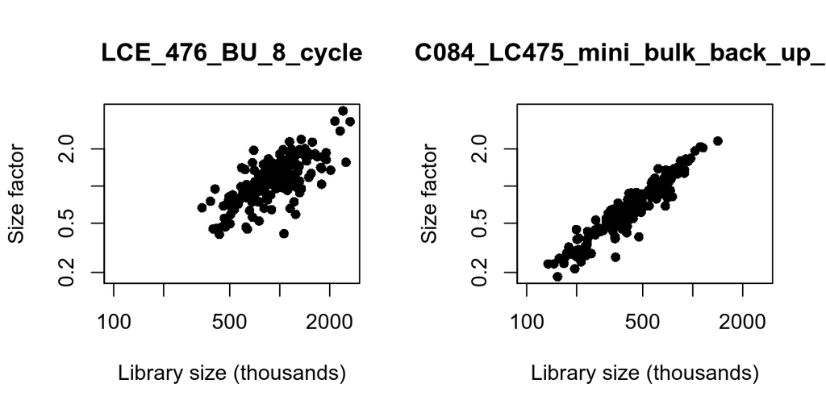

## Applying the size factors to normalize gene expression

## Computing separate size factors for spike-in transcripts

# Batch correction

# Feature selection

## Quantifying per-gene variation

### Variance of the log-counts

### Quantifying technical noise

### Accounting for blocking factors

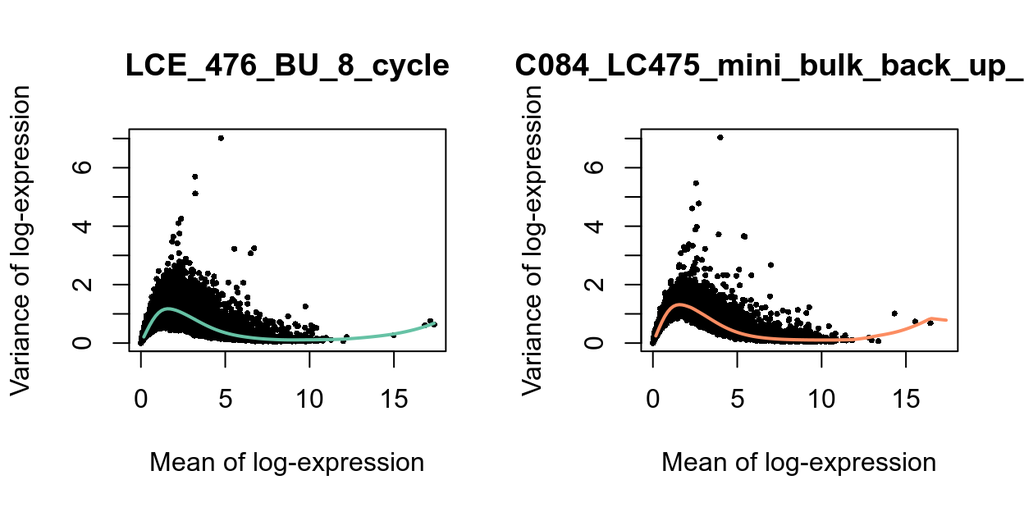

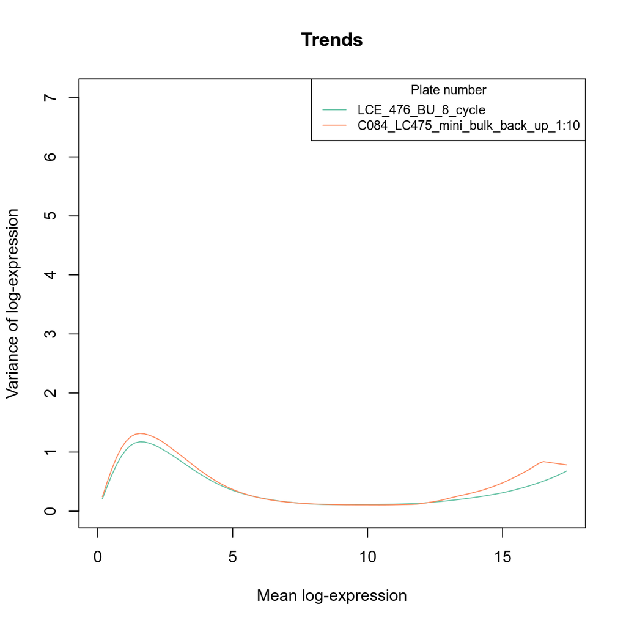

Figure 3: Cn overlay of the trend fits from the previous figure, highlighting the need for the batch-specific trend fits. Each line is a the trend line for a particular batch (with colours matching the previous plot).

## Selecting highly variable genes

There are 16890 HVGs by this approach.

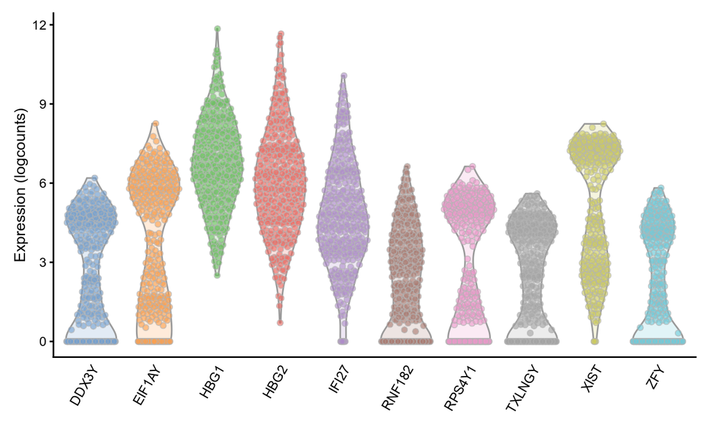

# Dimensionality reduction

## Principal component analysis

This retains 5 dimensions.

# Batch correction with MNN

**TODO:** Try MNN

## Application

```
       Batch
Cluster C084_LC475_mini_bulk_back_up_1:10 LCE_476_BU_8_cycle
      1                                47                 64
      2                                48                 39
      3                                42                 44
      4                                46                 29
```

# Visual inspection of merge results

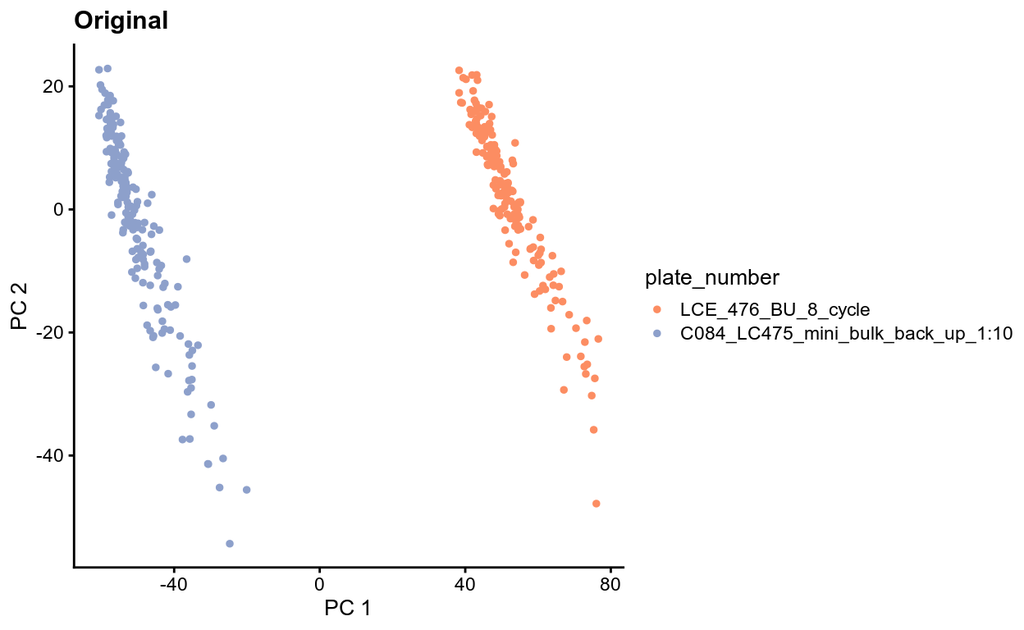

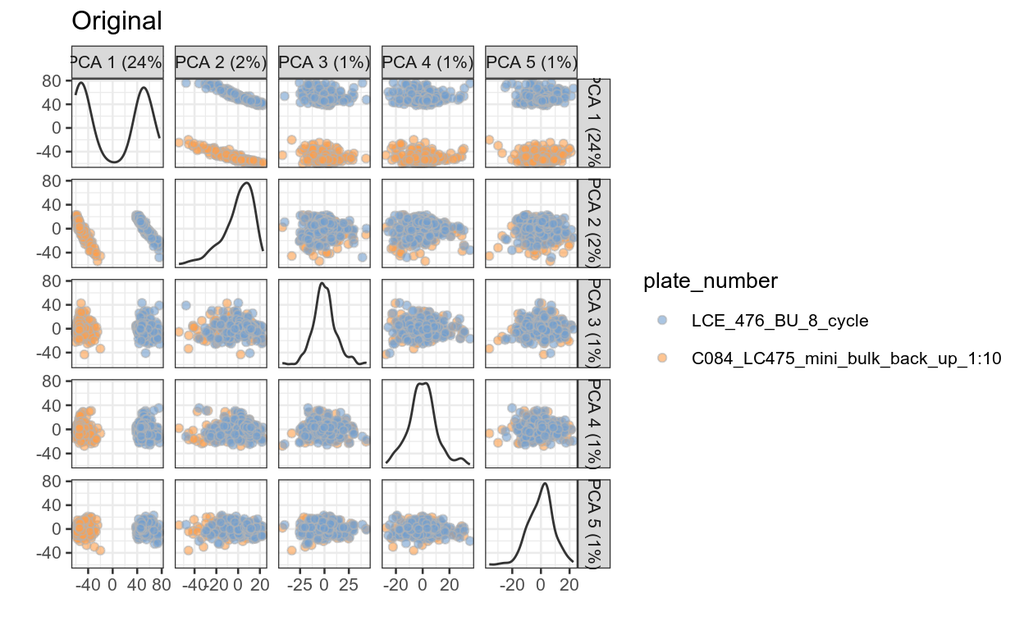

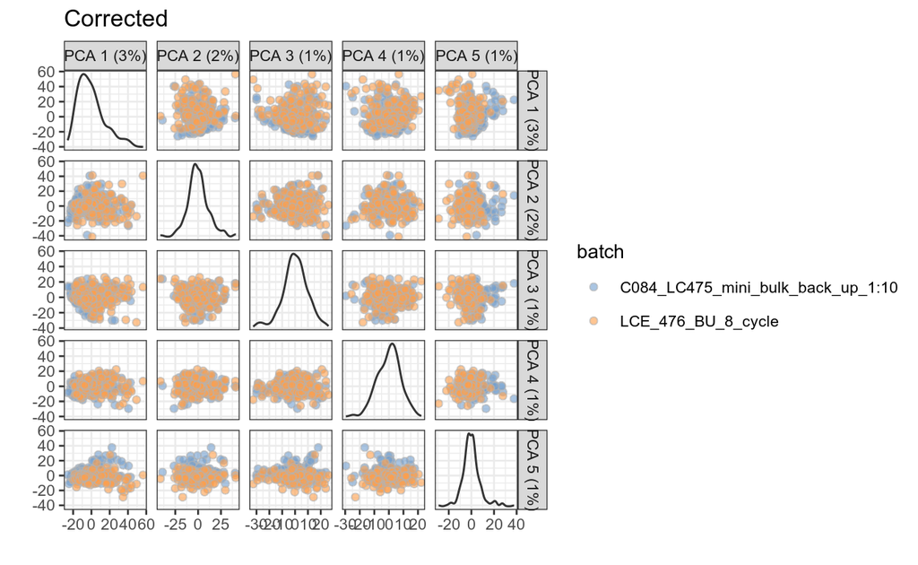

# DE analysis

```
keep
FALSE  TRUE
25021  7524
```

## placebo.endline_vs_baseline

```
       -1*placebo.baseline 1*placebo.endline
Down                                       3
NotSig                                  7512
Up                                         9
```

|  | ENSEMBL | SYMBOL | CHR | logFC | logCPM | F | PValue | FDR |
| --- | --- | --- | --- | --- | --- | --- | --- | --- |
| FOS | ENSG00000170345 | FOS | 14 | 1.2605501 | 7.828804 | 42.26058 | 2.733299e-10 | 2.056534e-06 |
| MT-ND4L | ENSG00000212907 | MT-ND4L | MT | -0.5127520 | 9.082971 | 28.00356 | 2.108691e-07 | 7.932897e-04 |
| DUSP1 | ENSG00000120129 | DUSP1 | 5 | 0.6584210 | 7.284058 | 22.92435 | 2.478519e-06 | 6.216126e-03 |
| MALAT1 | ENSG00000251562 | MALAT1 | 11 | -0.3325752 | 12.317203 | 19.72814 | 1.187373e-05 | 2.233450e-02 |
| ISCA1 | ENSG00000135070 | ISCA1 | 9 | 0.5448898 | 5.860792 | 19.12769 | 1.590380e-05 | 2.369200e-02 |
| AL356535.1 | ENSG00000213087 | AL356535.1 | 6 | 0.3613856 | 6.588437 | 18.53523 | 2.137266e-05 | 2.369200e-02 |
| WBP2 | ENSG00000132471 | WBP2 | 17 | 0.3836832 | 7.340740 | 18.47351 | 2.204200e-05 | 2.369200e-02 |
| CFL1 | ENSG00000172757 | CFL1 | 11 | 0.2912873 | 8.397009 | 17.53758 | 3.522490e-05 | 2.867875e-02 |
| TERF2IP | ENSG00000166848 | TERF2IP | 16 | 0.3657650 | 6.791096 | 17.34546 | 3.879369e-05 | 2.867875e-02 |
| FTH1P10 | ENSG00000223361 | FTH1P10 | 5 | 0.3445677 | 7.142598 | 17.25437 | 4.061146e-05 | 2.867875e-02 |

[output cut: 2 more lines]

### Interactive plot

Click here for interactive version

- Hover over points to see sample-wise expression
- Click on column names to sort by column
- Click rows on tables to highlight gene

## zinc_10mg_tab.endline_vs_baseline

```
       -1*zinc_10mg_tab.baseline 1*zinc_10mg_tab.endline
Down                                                   4
NotSig                                              7518
Up                                                     2
```

|  | ENSEMBL | SYMBOL | CHR | logFC | logCPM | F | PValue | FDR |
| --- | --- | --- | --- | --- | --- | --- | --- | --- |
| GPX4 | ENSG00000167468 | GPX4 | 19 | 0.4952533 | 5.371731 | 27.78913 | 2.301330e-07 | 0.001731521 |
| FOS | ENSG00000170345 | FOS | 14 | 0.8805705 | 7.828804 | 24.72816 | 1.033111e-06 | 0.003886565 |
| MTRNR2L12 | ENSG00000269028 | MTRNR2L12 | 3 | -0.6029300 | 10.175903 | 23.05653 | 2.328933e-06 | 0.005840965 |
| MT-RNR2 | ENSG00000210082 | MT-RNR2 | MT | -0.3660950 | 14.970850 | 21.96240 | 3.972665e-06 | 0.007472584 |
| MT-ND4L | ENSG00000212907 | MT-ND4L | MT | -0.4094610 | 9.082971 | 20.74979 | 7.174652e-06 | 0.010796417 |
| UBR1 | ENSG00000159459 | UBR1 | 15 | -0.4576466 | 6.400920 | 20.24501 | 9.128693e-06 | 0.011447381 |

### Interactive plot

Click here for interactive version

- Hover over points to see sample-wise expression
- Click on column names to sort by column
- Click rows on tables to highlight gene

## high_zinc_low_iron_mnp.endline_vs_baseline

```
       -1*high_zinc_low_iron_mnp.baseline 1*high_zinc_low_iron_mnp.endline
Down                                                                    32
NotSig                                                                7442
Up                                                                      50
```

|  | ENSEMBL | SYMBOL | CHR | logFC | logCPM | F | PValue | FDR |
| --- | --- | --- | --- | --- | --- | --- | --- | --- |
| MT-ND4L | ENSG00000212907 | MT-ND4L | MT | -0.6732036 | 9.082971 | 44.35929 | 1.024049e-10 | 7.704947e-07 |
| CFL1 | ENSG00000172757 | CFL1 | 11 | 0.3842430 | 8.397009 | 28.98391 | 1.297279e-07 | 4.880363e-04 |
| IKZF2 | ENSG00000030419 | IKZF2 | 2 | -0.6178937 | 5.981401 | 24.91532 | 9.231015e-07 | 2.018127e-03 |
| UBA52 | ENSG00000221983 | UBA52 | 19 | 0.3955714 | 9.880824 | 24.61044 | 1.072901e-06 | 2.018127e-03 |
| SERF2 | ENSG00000140264 | SERF2 | 15 | 0.4364036 | 8.807717 | 23.05000 | 2.302812e-06 | 3.465271e-03 |
| VCPIP1 | ENSG00000175073 | VCPIP1 | 8 | -0.5247746 | 6.390189 | 21.00267 | 6.275103e-06 | 7.868979e-03 |
| FOS | ENSG00000170345 | FOS | 14 | 0.8879614 | 7.828804 | 20.21612 | 9.399348e-06 | 1.003132e-02 |
| YPEL3 | ENSG00000090238 | YPEL3 | 16 | 0.5009165 | 7.681026 | 19.93297 | 1.073460e-05 | 1.003132e-02 |
| FEM1B | ENSG00000169018 | FEM1B | 15 | -0.5320375 | 5.401796 | 19.40429 | 1.385795e-05 | 1.003132e-02 |
| PFDN5 | ENSG00000123349 | PFDN5 | 12 | 0.3735733 | 6.532878 | 19.08407 | 1.625323e-05 | 1.003132e-02 |

[output cut: 72 more lines]

### Interactive plot

Click here for interactive version

- Hover over points to see sample-wise expression
- Click on column names to sort by column
- Click rows on tables to highlight gene

## endline.zinc_10mg_tab_vs_placebo

```
       -1*placebo.endline 1*zinc_10mg_tab.endline
Down                                            0
NotSig                                       7524
Up                                              0
```

### Interactive plot

Click here for interactive version

- Hover over points to see sample-wise expression
- Click on column names to sort by column
- Click rows on tables to highlight gene

## endline.high_zinc_low_iron_mnp_vs_placebo

```
       1*high_zinc_low_iron_mnp.endline -1*placebo.endline
Down                                                     0
NotSig                                                7524
Up                                                       0
```

### Interactive plot

Click here for interactive version

- Hover over points to see sample-wise expression
- Click on column names to sort by column
- Click rows on tables to highlight gene

## Summary

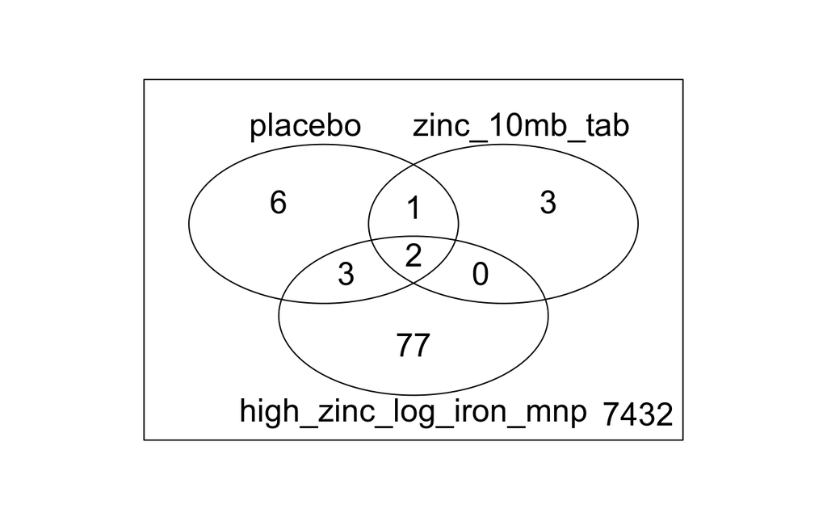

# TODO

- Pairwise plots of logcounts for each sample to compare the two batches